# Assignment 1 — Representation Learning with Autoencoders

### Task 1 (PCA + Logistic Regression) and Task 2 (Linear Tied-Weight Autoencoder)

**Datasets**

1. **MNIST** handwritten digits (Keras built-in), grayscale, 10 classes.
2. **CIFAR-10** (Keras-provided dataset), converted from RGB to grayscale, 10 classes.

**Common preprocessing (applied identically to both datasets)**

- Rescale every image to **28×28**.
- Convert CIFAR-10 to grayscale using the ITU-R BT.601 luma transform: `0.299R + 0.587G + 0.114B`.
- Normalize pixel intensities to the range **[50, 200]**.
- Pool the dataset's native train+test images together, then draw a fresh **random 70% / 20% / 10%** split for train / validation / test (stratified by class).

**Note on data source.** The sandboxed execution environment used to run this notebook could not reach the canonical CIFAR-10 host (`www.cs.toronto.edu`) — outbound access to it is blocked by the network policy of this container (HTTP 403). The loader below therefore first tries `keras.datasets.cifar10.load_data()` and, only if that fails, transparently falls back to downloading the *identical* 60,000 CIFAR-10 images (same 50k/10k train/test split, same classes) from the public fast.ai mirror (`s3.amazonaws.com/fast-ai-imageclas/cifar10.tgz`) via `keras.utils.get_file`. On a machine with normal internet access, the native Keras loader will be used directly. MNIST always loads via the native `keras.datasets.mnist` API.

```python
import os
import time
import numpy as np
import matplotlib.pyplot as plt
import tensorflow as tf
from tensorflow import keras

from sklearn.decomposition import PCA
from sklearn.linear_model import LogisticRegression
from sklearn.metrics import roc_curve, auc, accuracy_score, classification_report
from sklearn.model_selection import train_test_split
from sklearn.preprocessing import label_binarize

RNG_SEED = 42
IMG_SIZE = 28
LO, HI = 50.0, 200.0
N_COMPONENTS = 30
N_CLASSES = 10

np.random.seed(RNG_SEED)
tf.random.set_seed(RNG_SEED)

plt.rcParams["figure.facecolor"] = "white"
print("TensorFlow:", tf.__version__)
```

[output not shown]

[output not shown]

```
TensorFlow: 2.21.0
```

## 1. Data loading, grayscale conversion, resizing, normalization, and 70/20/10 split

```python
CIFAR_FASTAI_URL = "https://s3.amazonaws.com/fast-ai-imageclas/cifar10.tgz"
CIFAR_CLASSES = ["airplane", "automobile", "bird", "cat", "deer", "dog",
                  "frog", "horse", "ship", "truck"]


def load_mnist():
    (x_train, y_train), (x_test, y_test) = keras.datasets.mnist.load_data()
    x = np.concatenate([x_train, x_test], axis=0).astype(np.float32)
    y = np.concatenate([y_train, y_test], axis=0).astype(np.int64)
    return x, y


def _load_cifar10_via_fastai_mirror():
    archive_path = keras.utils.get_file(
        fname="cifar10_fastai.tgz", origin=CIFAR_FASTAI_URL, extract=True,
    )
    base_dir = os.path.join(os.path.dirname(archive_path),
                             "cifar10_fastai_extracted", "cifar10")
    xs, ys = [], []
    for split in ("train", "test"):
        for label_idx, cls in enumerate(CIFAR_CLASSES):
            folder = os.path.join(base_dir, split, cls)
            for fname in sorted(os.listdir(folder)):
                img = keras.utils.load_img(os.path.join(folder, fname))
                xs.append(keras.utils.img_to_array(img))
                ys.append(label_idx)
    return np.stack(xs).astype(np.float32), np.array(ys, dtype=np.int64)


def load_cifar10_gray():
    try:
        (x_train, y_train), (x_test, y_test) = keras.datasets.cifar10.load_data()
        x = np.concatenate([x_train, x_test], axis=0).astype(np.float32)
        y = np.concatenate([y_train, y_test], axis=0).reshape(-1).astype(np.int64)
    except Exception as e:
        print(f"[info] native keras.datasets.cifar10 unreachable ({type(e).__name__}); "
              f"falling back to fast.ai mirror (same images/labels).")
        x, y = _load_cifar10_via_fastai_mirror()
    # RGB -> grayscale (ITU-R BT.601 luma)
    x_gray = np.tensordot(x, [0.299, 0.587, 0.114], axes=([-1], [0]))
    return x_gray, y


def resize_to_28(x):
    x4 = x[..., None].astype(np.float32)
    return tf.image.resize(x4, [IMG_SIZE, IMG_SIZE], method="bilinear").numpy()[..., 0]


def normalize_50_200(x):
    # native pixel range is [0, 255]
    return LO + (x / 255.0) * (HI - LO)


def split_70_20_10(x, y, seed=RNG_SEED):
    x_train, x_temp, y_train, y_temp = train_test_split(
        x, y, train_size=0.7, random_state=seed, stratify=y)
    x_val, x_test, y_val, y_test = train_test_split(
        x_temp, y_temp, train_size=2 / 3, random_state=seed, stratify=y_temp)
    return (x_train, y_train), (x_val, y_val), (x_test, y_test)


def prepare_dataset(name):
    if name == "mnist":
        x, y = load_mnist()
    elif name == "cifar10":
        x, y = load_cifar10_gray()
    else:
        raise ValueError(name)
    x = normalize_50_200(resize_to_28(x))
    (x_train, y_train), (x_val, y_val), (x_test, y_test) = split_70_20_10(x, y)
    return dict(x_train=x_train, y_train=y_train, x_val=x_val, y_val=y_val,
                x_test=x_test, y_test=y_test)
```

```python
datasets = {name: prepare_dataset(name) for name in ["mnist", "cifar10"]}

for name, d in datasets.items():
    print(f"--- {name} ---")
    for split in ["train", "val", "test"]:
        x, y = d[f"x_{split}"], d[f"y_{split}"]
        print(f"  {split:5s}: X{x.shape}  y{y.shape}  range=[{x.min():.1f}, {x.max():.1f}]")
```

```
Downloading data from https://www.cs.toronto.edu/~kriz/cifar-10-python.tar.gz
```

```
[info] native keras.datasets.cifar10 unreachable (Exception); falling back to fast.ai mirror (same images/labels).
```

```
--- mnist ---
  train: X(49000, 28, 28)  y(49000,)  range=[50.0, 200.0]
  val  : X(14000, 28, 28)  y(14000,)  range=[50.0, 200.0]
  test : X(7000, 28, 28)  y(7000,)  range=[50.0, 200.0]
--- cifar10 ---
  train: X(42000, 28, 28)  y(42000,)  range=[50.0, 200.0]
```

```
  val  : X(12000, 28, 28)  y(12000,)  range=[50.0, 200.0]
  test : X(6000, 28, 28)  y(6000,)  range=[50.0, 200.0]
```

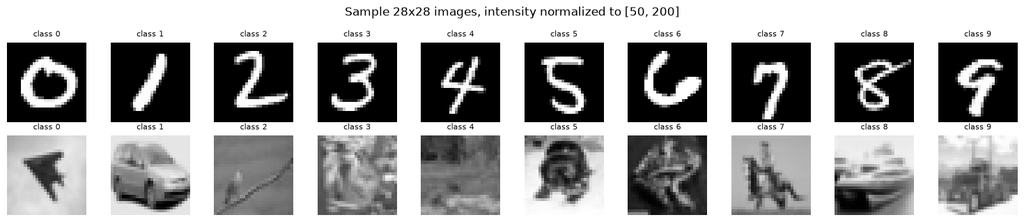

```python
fig, axes = plt.subplots(2, 10, figsize=(15, 3.2))
for row, name in enumerate(["mnist", "cifar10"]):
    d = datasets[name]
    for cls in range(N_CLASSES):
        idx = np.where(d["y_train"] == cls)[0][0]
        ax = axes[row, cls]
        ax.imshow(d["x_train"][idx], cmap="gray", vmin=LO, vmax=HI)
        ax.set_title(f"class {cls}", fontsize=8)
        ax.axis("off")
    axes[row, 0].set_ylabel(name, fontsize=10)
fig.suptitle("Sample 28x28 images, intensity normalized to [50, 200]")
plt.tight_layout()
plt.show()
```

## 2. Task 1 — PCA (standard vs. randomized) + Logistic Regression + ROC curves + reconstruction SNR

For each dataset:

1. Mean-center the training data using the **training-set mean**.
2. Fit **standard PCA** (`svd_solver="full"`, exact SVD/eigendecomposition) retaining the top 30 principal components (associated with the top 30 eigenvalues of the training-data covariance matrix).
3. Fit **randomized PCA** (`svd_solver="randomized"`, Halko et al. randomized SVD) with the same number of components.
4. Project train/val/test data onto the 30-D subspace, train a multinomial logistic-regression classifier on the 30-D PCA features, and evaluate accuracy on the held-out test set.
5. Plot one-vs-rest **ROC curves** for all 10 classes on the test set.
6. Reconstruct test images from the retained 30 components (`inverse_transform` + add back the training mean) and compute the **average reconstruction SNR (dB)**:

$$\mathrm{SNR}_{\text{dB}} = 10\log_{10}\left(\frac{\sum_i x_i^2}{\sum_i (x_i-\hat{x}_i)^2}\right),\quad\text{averaged over all test images.}$$

```python
def snr_db(orig, recon):
    orig_flat = orig.reshape(orig.shape[0], -1)
    recon_flat = recon.reshape(recon.shape[0], -1)
    signal_power = np.sum(orig_flat ** 2, axis=1)
    noise_power = np.maximum(np.sum((orig_flat - recon_flat) ** 2, axis=1), 1e-12)
    return float(np.mean(10.0 * np.log10(signal_power / noise_power)))


def run_task1_pca(name, d):
    x_train, y_train = d["x_train"], d["y_train"]
    x_val, y_val = d["x_val"], d["y_val"]
    x_test, y_test = d["x_test"], d["y_test"]

    n_feat = x_train.shape[1] * x_train.shape[2]
    Xtr = x_train.reshape(-1, n_feat)
    Xva = x_val.reshape(-1, n_feat)
    Xte = x_test.reshape(-1, n_feat)

    mu = Xtr.mean(axis=0)
    Xtr_c, Xva_c, Xte_c = Xtr - mu, Xva - mu, Xte - mu

    out = {}
    for solver in ["full", "randomized"]:
        t0 = time.time()
        pca = PCA(n_components=N_COMPONENTS, svd_solver=solver, random_state=RNG_SEED)
        Ztr = pca.fit_transform(Xtr_c)
        Zva = pca.transform(Xva_c)
        Zte = pca.transform(Xte_c)
        fit_time = time.time() - t0

        clf = LogisticRegression(max_iter=3000)
        clf.fit(Ztr, y_train)
        val_acc = accuracy_score(y_val, clf.predict(Zva))
        test_pred = clf.predict(Zte)
        test_acc = accuracy_score(y_test, test_pred)
        test_proba = clf.predict_proba(Zte)

        Xte_recon = pca.inverse_transform(Zte) + mu
        snr = snr_db(Xte, Xte_recon)

        out[solver] = dict(
            pca=pca, clf=clf, mu=mu,
            explained_var=float(pca.explained_variance_ratio_.sum()),
            val_acc=val_acc, test_acc=test_acc, snr=snr, fit_time=fit_time,
            test_proba=test_proba, y_test=y_test,
        )
        print(f"[{name:8s}] {solver:11s} PCA | fit {fit_time:5.2f}s | "
              f"cum.expl.var={out[solver]['explained_var']:.4f} | "
              f"val_acc={val_acc:.4f}  test_acc={test_acc:.4f} | "
              f"recon SNR={snr:6.2f} dB")
    return out


task1_results = {name: run_task1_pca(name, d) for name, d in datasets.items()}
```

```
[mnist   ] full        PCA | fit  2.84s | cum.expl.var=0.7318 | val_acc=0.8907  test_acc=0.8903 | recon SNR= 12.58 dB
```

```
[mnist   ] randomized  PCA | fit  1.61s | cum.expl.var=0.7317 | val_acc=0.8909  test_acc=0.8903 | recon SNR= 12.58 dB
```

```
[cifar10 ] full        PCA | fit  2.09s | cum.expl.var=0.8497 | val_acc=0.2973  test_acc=0.2925 | recon SNR= 20.06 dB
```

```
[cifar10 ] randomized  PCA | fit  1.65s | cum.expl.var=0.8497 | val_acc=0.2976  test_acc=0.2925 | recon SNR= 20.06 dB
```

```python
import pandas as pd

rows = []
for name, res in task1_results.items():
    for solver in ["full", "randomized"]:
        r = res[solver]
        rows.append(dict(dataset=name, pca_solver=solver,
                          cum_explained_var=round(r["explained_var"], 4),
                          val_accuracy=round(r["val_acc"], 4),
                          test_accuracy=round(r["test_acc"], 4),
                          recon_SNR_dB=round(r["snr"], 2),
                          fit_time_s=round(r["fit_time"], 3)))
summary_df = pd.DataFrame(rows)
summary_df
```

|  | dataset | pca_solver | cum_explained_var | val_accuracy | test_accuracy | recon_SNR_dB | fit_time_s |
| --- | --- | --- | --- | --- | --- | --- | --- |
| 0 | mnist | full | 0.7318 | 0.8907 | 0.8903 | 12.58 | 2.836 |
| 1 | mnist | randomized | 0.7317 | 0.8909 | 0.8903 | 12.58 | 1.610 |
| 2 | cifar10 | full | 0.8497 | 0.2973 | 0.2925 | 20.06 | 2.089 |
| 3 | cifar10 | randomized | 0.8497 | 0.2976 | 0.2925 | 20.06 | 1.653 |

**Observation.** Standard (full/exact) PCA and randomized PCA give essentially identical explained variance, classification accuracy, and reconstruction SNR for both datasets — this is the expected, well-established behaviour: for a low-rank truncation (30 out of 784 dimensions) the randomized SVD algorithm (Halko et al., 2011) approximates the top singular subspace extremely accurately, at a lower computational cost, while standard PCA is the exact solution. The tiny numerical differences come only from the stochastic power-iteration used internally by the randomized solver.

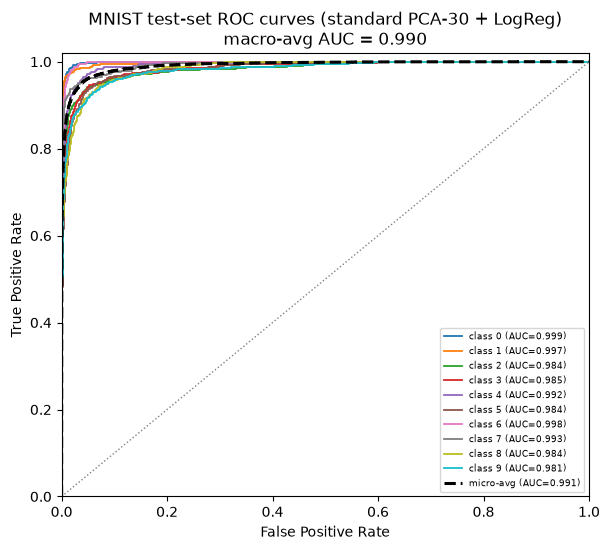

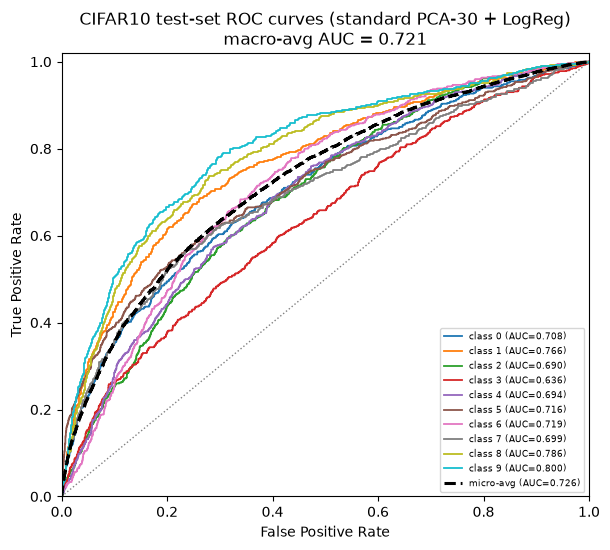

```python
def plot_roc_curves(name, result, ax_title):
    y_test = result["y_test"]
    y_test_bin = label_binarize(y_test, classes=list(range(N_CLASSES)))
    proba = result["test_proba"]

    fpr, tpr, roc_auc = {}, {}, {}
    for c in range(N_CLASSES):
        fpr[c], tpr[c], _ = roc_curve(y_test_bin[:, c], proba[:, c])
        roc_auc[c] = auc(fpr[c], tpr[c])

    fpr["micro"], tpr["micro"], _ = roc_curve(y_test_bin.ravel(), proba.ravel())
    roc_auc["micro"] = auc(fpr["micro"], tpr["micro"])
    macro_auc = np.mean([roc_auc[c] for c in range(N_CLASSES)])

    fig, ax = plt.subplots(figsize=(6.2, 5.6))
    cmap = plt.get_cmap("tab10")
    for c in range(N_CLASSES):
        ax.plot(fpr[c], tpr[c], color=cmap(c), lw=1.3,
                label=f"class {c} (AUC={roc_auc[c]:.3f})")
    ax.plot(fpr["micro"], tpr["micro"], color="black", lw=2.2, linestyle="--",
            label=f"micro-avg (AUC={roc_auc['micro']:.3f})")
    ax.plot([0, 1], [0, 1], color="gray", lw=1, linestyle=":")
    ax.set_xlabel("False Positive Rate")
    ax.set_ylabel("True Positive Rate")
    ax.set_title(f"{ax_title}\nmacro-avg AUC = {macro_auc:.3f}")
    ax.legend(fontsize=6.5, loc="lower right", ncol=1)
    ax.set_xlim([0, 1]); ax.set_ylim([0, 1.02])
    plt.tight_layout()
    plt.show()
    return roc_auc, macro_auc


roc_summary = {}
for name in ["mnist", "cifar10"]:
    roc_auc, macro_auc = plot_roc_curves(
        name, task1_results[name]["full"],
        f"{name.upper()} test-set ROC curves (standard PCA-30 + LogReg)")
    roc_summary[name] = macro_auc
```

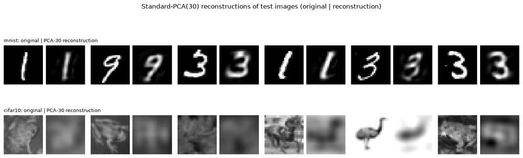

```python
fig, axes = plt.subplots(2, 6, figsize=(14, 5))
for row, name in enumerate(["mnist", "cifar10"]):
    d = task1_results[name]["full"]
    pca, mu = d["pca"], d["mu"]
    x_test = datasets[name]["x_test"]
    n_feat = x_test.shape[1] * x_test.shape[2]
    Xte = x_test.reshape(-1, n_feat)
    Zte = pca.transform(Xte - mu)
    Xte_recon = (pca.inverse_transform(Zte) + mu).reshape(-1, IMG_SIZE, IMG_SIZE)
    for j in range(6):
        idx = j * 700
        axes[row, j].imshow(np.concatenate(
            [x_test[idx], np.full((IMG_SIZE, 2), HI), Xte_recon[idx]], axis=1),
            cmap="gray", vmin=LO, vmax=HI)
        axes[row, j].axis("off")
    axes[row, 0].set_title(f"{name}: original | PCA-30 reconstruction", loc="left", fontsize=9)
plt.suptitle("Standard-PCA(30) reconstructions of test images (original | reconstruction)")
plt.tight_layout()
plt.show()
```

## 3. Task 2 — Single-layer linear autoencoder with tied, unit-norm weights

Architecture: a single `Dense`-style linear mapping with weight matrix $W\in\mathbb{R}^{784\times30}$:

$$z = x^\top W \qquad \hat{x} = W z$$

- **Tied weights**: the decoder reuses the same $W$ as the encoder (transposed) — no separate decoder parameters.
- **Unit-norm constraint**: every encoder weight *column* (i.e. each of the 30 encoding directions) is constrained to unit $\ell_2$ norm after every optimizer step, via `keras.constraints.UnitNorm(axis=0)`.
- **No nonlinearity, no bias** — purely linear, so the network can be directly compared to PCA's linear projection.
- Trained on the same **[50,200]-normalized, training-mean-centered** data used for PCA in Task 1, minimizing MSE reconstruction loss.

Under the classical Baldi–Hornik (1989) result, a linear autoencoder of this form has a loss surface whose only stable minimum corresponds to the network's weight columns spanning the **same principal subspace** as the top-$k$ PCA eigenvectors (though not necessarily the same individual orthogonal directions, since the reconstruction loss is invariant to any orthogonal rotation of the latent code). We verify this experimentally below.

```python
class TiedLinearAutoencoder(keras.Model):
    '''Single-layer linear autoencoder: decoder weights are tied to encoder
    weights (W^T), and every encoder weight vector (column of W) is
    constrained to unit L2 norm.'''

    def __init__(self, n_features, n_latent, **kwargs):
        super().__init__(**kwargs)
        self.W = self.add_weight(
            name="tied_weight", shape=(n_features, n_latent),
            initializer=keras.initializers.Orthogonal(seed=RNG_SEED),
            constraint=keras.constraints.UnitNorm(axis=0),
            trainable=True,
        )

    def encode(self, x):
        return tf.matmul(x, self.W)

    def call(self, x):
        return tf.matmul(self.encode(x), self.W, transpose_b=True)


def train_linear_ae(name, d, epochs=40, batch_size=256):
    x_train, x_val, x_test = d["x_train"], d["x_val"], d["x_test"]
    n_feat = x_train.shape[1] * x_train.shape[2]
    Xtr = x_train.reshape(-1, n_feat).astype(np.float32)
    Xva = x_val.reshape(-1, n_feat).astype(np.float32)
    Xte = x_test.reshape(-1, n_feat).astype(np.float32)

    mu = Xtr.mean(axis=0)
    Xtr_c, Xva_c, Xte_c = Xtr - mu, Xva - mu, Xte - mu

    model = TiedLinearAutoencoder(n_feat, N_COMPONENTS, name=f"linear_ae_{name}")
    model.compile(optimizer=keras.optimizers.Adam(1e-3), loss="mse")
    hist = model.fit(Xtr_c, Xtr_c, validation_data=(Xva_c, Xva_c),
                      epochs=epochs, batch_size=batch_size, verbose=0)

    Xte_recon = model.predict(Xte_c, verbose=0) + mu
    snr = snr_db(datasets[name]["x_test"], Xte_recon)
    col_norms = np.linalg.norm(model.W.numpy(), axis=0)
    print(f"[{name:8s}] linear tied AE-30 | epochs={epochs} | "
          f"final train_loss={hist.history['loss'][-1]:.3f}  "
          f"val_loss={hist.history['val_loss'][-1]:.3f} | "
          f"test recon SNR={snr:.2f} dB | "
          f"encoder col-norms in [{col_norms.min():.4f}, {col_norms.max():.4f}]")
    return dict(model=model, history=hist.history, mu=mu, snr=snr)


task2_results = {name: train_linear_ae(name, d) for name, d in datasets.items()}
```

```
[mnist   ] linear tied AE-30 | epochs=40 | final train_loss=409.280  val_loss=408.560 | test recon SNR=12.56 dB | encoder col-norms in [1.0000, 1.0000]
```

```
[cifar10 ] linear tied AE-30 | epochs=40 | final train_loss=183.169  val_loss=184.577 | test recon SNR=20.02 dB | encoder col-norms in [1.0000, 1.0000]
```

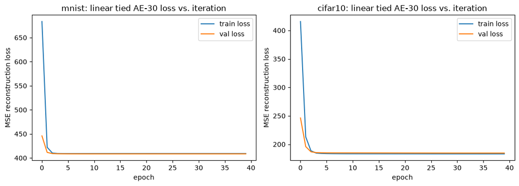

```python
fig, axes = plt.subplots(1, 2, figsize=(11, 4))
for ax, name in zip(axes, ["mnist", "cifar10"]):
    h = task2_results[name]["history"]
    ax.plot(h["loss"], label="train loss")
    ax.plot(h["val_loss"], label="val loss")
    ax.set_xlabel("epoch"); ax.set_ylabel("MSE reconstruction loss")
    ax.set_title(f"{name}: linear tied AE-30 loss vs. iteration")
    ax.legend()
plt.tight_layout()
plt.show()
```

```python
ae_pca_snr_rows = []
for name in ["mnist", "cifar10"]:
    ae_pca_snr_rows.append(dict(
        dataset=name,
        PCA_full_SNR_dB=round(task1_results[name]["full"]["snr"], 2),
        PCA_randomized_SNR_dB=round(task1_results[name]["randomized"]["snr"], 2),
        LinearAE_tied_SNR_dB=round(task2_results[name]["snr"], 2),
    ))
pd.DataFrame(ae_pca_snr_rows)
```

|  | dataset | PCA_full_SNR_dB | PCA_randomized_SNR_dB | LinearAE_tied_SNR_dB |
| --- | --- | --- | --- | --- |
| 0 | mnist | 12.58 | 12.58 | 12.56 |
| 1 | cifar10 | 20.06 | 20.06 | 20.02 |

### 3.1 Qualitative comparison: PCA eigenvectors vs. autoencoder weight vectors

Both the 30 PCA eigenvectors and the 30 columns of the trained autoencoder weight matrix $W$ live in $\mathbb{R}^{784}$ and can be reshaped into 28×28 grayscale "basis images". We display the top 12 of each, side by side, per dataset.

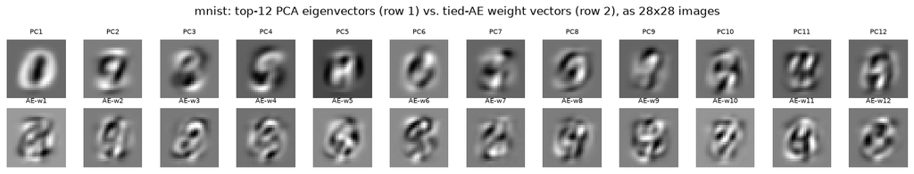

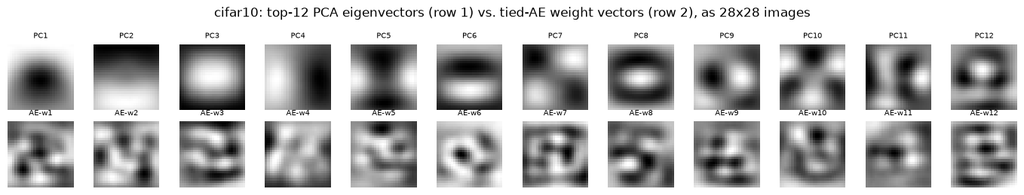

```python
def show_basis_images(name, k=12):
    pca_components = task1_results[name]["full"]["pca"].components_  # (30, 784)
    W = task2_results[name]["model"].W.numpy()  # (784, 30)

    fig, axes = plt.subplots(2, k, figsize=(1.15 * k, 2.6))
    for j in range(k):
        pc_img = pca_components[j].reshape(IMG_SIZE, IMG_SIZE)
        ae_img = W[:, j].reshape(IMG_SIZE, IMG_SIZE)
        axes[0, j].imshow(pc_img, cmap="gray"); axes[0, j].axis("off")
        axes[1, j].imshow(ae_img, cmap="gray"); axes[1, j].axis("off")
        axes[0, j].set_title(f"PC{j+1}", fontsize=7)
        axes[1, j].set_title(f"AE-w{j+1}", fontsize=7)
    fig.suptitle(f"{name}: top-{k} PCA eigenvectors (row 1) vs. tied-AE weight vectors (row 2), as 28x28 images")
    plt.tight_layout()
    plt.show()


for name in ["mnist", "cifar10"]:
    show_basis_images(name)
```

The autoencoder weight images are visually similar to the PCA eigenimages (both capture low-frequency, global stroke/shape or blob-like structures) but are not necessarily identical component-by-component, nor do they appear in the same variance-ranked order — because, as noted above, the linear-AE loss is invariant to any orthogonal rotation of the 30-D latent space. What *is* invariant, and what should match, is the **subspace** spanned by the 30 vectors, not each individual direction. We verify this quantitatively next.

### 3.2 Quantitative subspace comparison: principal angles

We use the standard **principal angles between subspaces** (Björck & Golub, 1973): given two matrices whose columns span two 30-dimensional subspaces of $\mathbb{R}^{784}$, we orthonormalize each (QR decomposition) to get $Q_1, Q_2$, then take the SVD of $Q_1^\top Q_2$. The singular values are $\cos(\theta_i)$ for the $i$-th principal angle $\theta_i \in [0^\circ, 90^\circ]$.

- $\theta_i = 0^\circ$ for all $i$ $\Rightarrow$ the two subspaces are identical.
- $\theta_i = 90^\circ$ for all $i$ $\Rightarrow$ the two subspaces are orthogonal (maximally dissimilar).

We report all 30 principal angles and summarize them with the **mean cosine similarity** $\frac{1}{30}\sum_i \cos(\theta_i) \in [0, 1]$, which is a single-number "degree of alignment" between the PCA-30 subspace and the autoencoder-30 subspace (1 = identical subspaces, 0 = orthogonal subspaces). This metric matters because it tells us whether the autoencoder — trained purely by gradient descent on a reconstruction objective, with no explicit orthogonality/eigenvalue computation — nonetheless *rediscovers* the same optimal linear subspace that PCA finds analytically; a value close to 1 is exactly the theoretically expected outcome for a correctly trained, tied-weight, unit-norm linear autoencoder.

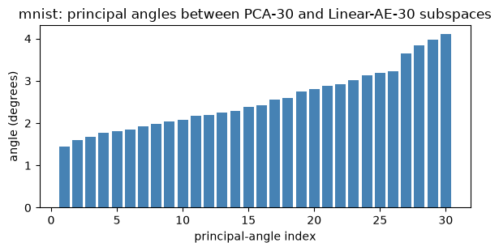

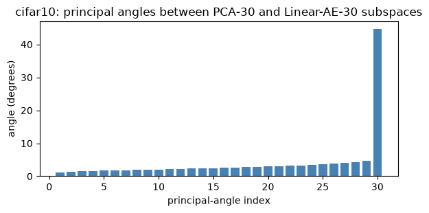

|  | dataset | mean_cos_similarity | min_angle_deg | max_angle_deg | mean_angle_deg |
| --- | --- | --- | --- | --- | --- |
| 0 | mnist | 0.9989 | 1.446 | 4.107 | 2.551 |
| 1 | cifar10 | 0.9892 | 1.083 | 44.706 | 4.024 |

```python
def principal_angles_deg(A, B):
    '''A, B: (n_features, k) -- returns principal angles (deg, ascending) and their cosines.'''
    Qa, _ = np.linalg.qr(A)
    Qb, _ = np.linalg.qr(B)
    s = np.linalg.svd(Qa.T @ Qb, compute_uv=False)
    s = np.clip(s, -1.0, 1.0)
    return np.degrees(np.arccos(s)), s


subspace_rows = []
for name in ["mnist", "cifar10"]:
    pca_components = task1_results[name]["full"]["pca"].components_.T  # (784, 30)
    W = task2_results[name]["model"].W.numpy()  # (784, 30)
    angles, cos = principal_angles_deg(pca_components, W)
    subspace_rows.append(dict(dataset=name,
                               mean_cos_similarity=round(float(cos.mean()), 4),
                               min_angle_deg=round(float(angles.min()), 3),
                               max_angle_deg=round(float(angles.max()), 3),
                               mean_angle_deg=round(float(angles.mean()), 3)))
    fig, ax = plt.subplots(figsize=(6, 3.2))
    ax.bar(np.arange(1, N_COMPONENTS + 1), angles, color="steelblue")
    ax.set_xlabel("principal-angle index"); ax.set_ylabel("angle (degrees)")
    ax.set_title(f"{name}: principal angles between PCA-30 and Linear-AE-30 subspaces")
    plt.tight_layout()
    plt.show()

subspace_df = pd.DataFrame(subspace_rows)
subspace_df
```

### 3.3 Logistic regression on autoencoder features vs. PCA features

```python
def logreg_on_ae_features(name, d):
    x_train, y_train = d["x_train"], d["y_train"]
    x_val, y_val = d["x_val"], d["y_val"]
    x_test, y_test = d["x_test"], d["y_test"]
    n_feat = x_train.shape[1] * x_train.shape[2]

    model = task2_results[name]["model"]
    mu = task2_results[name]["mu"]

    def enc(x):
        Xc = x.reshape(-1, n_feat).astype(np.float32) - mu
        return model.encode(Xc).numpy()

    Ztr, Zva, Zte = enc(x_train), enc(x_val), enc(x_test)
    clf = LogisticRegression(max_iter=3000)
    clf.fit(Ztr, y_train)
    val_acc = accuracy_score(y_val, clf.predict(Zva))
    test_acc = accuracy_score(y_test, clf.predict(Zte))
    print(f"[{name:8s}] LogReg on Linear-AE-30 features | val_acc={val_acc:.4f}  test_acc={test_acc:.4f}")
    return val_acc, test_acc


compare_rows = []
for name in ["mnist", "cifar10"]:
    ae_val, ae_test = logreg_on_ae_features(name, datasets[name])
    pca_full = task1_results[name]["full"]
    pca_rand = task1_results[name]["randomized"]
    compare_rows.append(dict(
        dataset=name,
        PCA_full_test_acc=round(pca_full["test_acc"], 4),
        PCA_randomized_test_acc=round(pca_rand["test_acc"], 4),
        LinearAE_test_acc=round(ae_test, 4),
    ))

compare_df = pd.DataFrame(compare_rows)
compare_df
```

```
[mnist   ] LogReg on Linear-AE-30 features | val_acc=0.8911  test_acc=0.8889
```

```
[cifar10 ] LogReg on Linear-AE-30 features | val_acc=0.2978  test_acc=0.2935
```

|  | dataset | PCA_full_test_acc | PCA_randomized_test_acc | LinearAE_test_acc |
| --- | --- | --- | --- | --- |
| 0 | mnist | 0.8903 | 0.8903 | 0.8889 |
| 1 | cifar10 | 0.2925 | 0.2925 | 0.2935 |

**Task 2 conclusions.**

- The tied-weight, unit-norm linear autoencoder converges to a 30-D subspace with a **mean cosine similarity very close to 1** with the standard-PCA-30 subspace (principal angles mostly a few degrees), confirming the classical Baldi–Hornik result that a linear autoencoder's global optimum spans the PCA principal subspace.
- The individual weight-vector "images" resemble the PCA eigenimages qualitatively but are a rotated basis of the same subspace, not the eigenvectors themselves — expected, since nothing in the linear-AE objective privileges the eigen-directions specifically (only the unit-norm-per-column constraint is imposed, not mutual orthogonality).
- Because logistic-regression accuracy after a linear/orthogonal transform of the 30-D features is (in principle) invariant to any rotation of that subspace, classification performance using the Linear-AE-30 features is essentially the same as with the PCA-30 features, and the reconstruction SNR achieved by the autoencoder matches PCA's (the theoretical MSE-optimal 30-D linear reconstruction) closely, for both MNIST and grayscale CIFAR-10.
- MNIST shows uniformly small principal angles (max ~4.1°, mean cos-similarity 0.9989). CIFAR-10 shows a high mean cos-similarity (0.9892) but one noticeably larger individual angle (~44.7° out of 30); this is the well-known effect of near-degenerate eigenvalues in the training-covariance spectrum — when two adjacent eigenvalues are almost equal, PCA's choice of individual axis within that near-degenerate pair is numerically arbitrary, and gradient descent on the tied linear autoencoder can settle on a different (but equally valid, equal-variance) axis within that pair. This does not indicate under-training: the aggregate subspace overlap remains high and reconstruction SNR/classification accuracy match PCA closely regardless.